# MNIST_GAN_Exercise

Summary of *My Notes*:

`torch.nn` vs `torch.nn.functional`

- `torch.nn` is stateful, `torch.nn.functional` is stateless.
- `torch.nn` handles the turning on/off for evaluation mode, while `torch.nn.functional` doesn't care about evaluation/prediciton mode.
- Dropout is usually considered as stateful, while functions like ReLU are stateless, as it doesn't have weights to update/keep track of.

https://discuss.pytorch.org/t/how-to-choose-between-torch-nn-functional-and-torch-nn-module/2800/25

https://stackoverflow.com/a/53452827

When to init functional layers in **init** and when not to:

- `torch.nn` needs to be initialized so the state can be tracked.

real_loss vs fake_loss:

- Only real_loss needs label smoothing while fake loss doesn't need one.
- real_loss uses `torch.ones()` while fake_loss uses `torch.zeros()`.
- set the Generator to eval mode for sample generation `G.eval()`, as it accounts for the different behavior that a dropout layer has during training vs during model evaluation.
- When generating fake images, the line `with torch.no_grad()` is only used for discriminator, but not for generator. https://datascience.stackexchange.com/a/71598

When to use: `torch.no_grad()` is generally used to perform validation.

1. to perform inference without gradient calculation.
2. to make sure there's not leak test data into the model.

About `torch.autograd()`: https://pytorch.org/tutorials/beginner/blitz/autograd_tutorial.html#gradients

# Generative Adversarial Network

In this notebook, we'll be building a generative adversarial network (GAN) trained on the MNIST dataset. From this, we'll be able to generate new handwritten digits!

GANs were [first reported on](https://arxiv.org/abs/1406.2661) in 2014 from Ian Goodfellow and others in Yoshua Bengio's lab. Since then, GANs have exploded in popularity. Here are a few examples to check out:

- [Pix2Pix](https://affinelayer.com/pixsrv/)
- [CycleGAN & Pix2Pix in PyTorch, Jun-Yan Zhu](https://github.com/junyanz/pytorch-CycleGAN-and-pix2pix)
- [A list of generative models](https://github.com/wiseodd/generative-models)

The idea behind GANs is that you have two networks, a generator $G$ and a discriminator $D$, competing against each other. The generator makes "fake" data to pass to the discriminator. The discriminator also sees real training data and predicts if the data it's received is real or fake.

> - The generator is trained to fool the discriminator, it wants to output data that looks *as close as possible* to real, training data.
> - The discriminator is a classifier that is trained to figure out which data is real and which is fake.

What ends up happening is that the generator learns to make data that is indistinguishable from real data to the discriminator.

[figure not shown]

The general structure of a GAN is shown in the diagram above, using MNIST images as data. The latent sample is a random vector that the generator uses to construct its fake images. This is often called a **latent vector** and that vector space is called **latent space**. As the generator trains, it figures out how to map latent vectors to recognizable images that can fool the discriminator.

If you're interested in generating only new images, you can throw out the discriminator after training. In this notebook, I'll show you how to define and train these adversarial networks in PyTorch and generate new images!

```python
%matplotlib inline

import numpy as np
import torch
import matplotlib.pyplot as plt
```

```python
from torchvision import datasets
import torchvision.transforms as transforms

# number of subprocesses to use for data loading
num_workers = 0
# how many samples per batch to load
batch_size = 64

# convert data to torch.FloatTensor
transform = transforms.ToTensor()

# get the training datasets
train_data = datasets.MNIST(root='data', train=True,
                                   download=True, transform=transform)

# prepare data loader
train_loader = torch.utils.data.DataLoader(train_data, batch_size=batch_size,
                                           num_workers=num_workers)
```

### Visualize the data

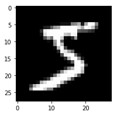

```python
# obtain one batch of training images
dataiter = iter(train_loader)
images, labels = dataiter.next()
images = images.numpy()

# get one image from the batch
img = np.squeeze(images[0])

fig = plt.figure(figsize = (3,3))
ax = fig.add_subplot(111)
ax.imshow(img, cmap='gray')
```

# Define the Model

A GAN is comprised of two adversarial networks, a discriminator and a generator.

## Discriminator

The discriminator network is going to be a pretty typical linear classifier. To make this network a universal function approximator, we'll need at least one hidden layer, and these hidden layers should have one key attribute:

> All hidden layers will have a [Leaky ReLu](https://pytorch.org/docs/stable/nn.html#torch.nn.LeakyReLU) activation function applied to their outputs.

[figure not shown]

#### Leaky ReLu

We should use a leaky ReLU to allow gradients to flow backwards through the layer unimpeded. A leaky ReLU is like a normal ReLU, except that there is a small non-zero output for negative input values.

[figure not shown]

#### Sigmoid Output

We'll also take the approach of using a more numerically stable loss function on the outputs. Recall that we want the discriminator to output a value 0-1 indicating whether an image is *real or fake*.

> We will ultimately use [BCEWithLogitsLoss](https://pytorch.org/docs/stable/nn.html#bcewithlogitsloss), which combines a `sigmoid` activation function **and** and binary cross entropy loss in one function.

So, our final output layer should not have any activation function applied to it.

*My Notes*

`torch.nn` vs `torch.nn.functional`

- `torch.nn` is stateful, `torch.nn.functional` is stateless.
- `torch.nn` handles the turning on/off for evaluation mode, while `torch.nn.functional` doesn't care about evaluation/prediciton mode.
- Dropout is usually considered as stateful, while functions like ReLU are stateless, as it doesn't have weights to update/keep track of.

https://discuss.pytorch.org/t/how-to-choose-between-torch-nn-functional-and-torch-nn-module/2800/25

https://stackoverflow.com/a/53452827

When to init functional layers in **init** and when not to:

- `torch.nn` needs to be initialized so the state can be tracked.

```python
import torch.nn as nn
import torch.nn.functional as F

# class Discriminator(nn.Module):

#     def __init__(self, input_size, hidden_dim, output_size):
#         super(Discriminator, self).__init__()

#         # define all layers

#         ## hidden layer(s)
#         self.fc1 = nn.Linear(input_size, hidden_dim)
#         ## final layer
#         self.fc_final = nn.Linear(hidden_dim, output_size)

#         ## functional layers
#         self.lrelu = nn.LeakyReLU(0.2)
#         self.dropout = nn.Dropout(0.3)


#     def forward(self, x):
#         # flatten image
#         x = x.view(-1, 28*28) # x = x.view(-1, 28*28)

#         # pass x through all layers
#         # apply leaky relu activation to all hidden layers
#         x = self.dropout(self.lrelu(self.fc1(x)))
#         x = self.fc_final(x)

#         return x


class Discriminator(nn.Module):

    def __init__(self, input_size, hidden_dim, output_size):
        super(Discriminator, self).__init__()

        ## hidden layers
        self.fc1 = nn.Linear(input_size, hidden_dim*4)
        self.fc2 = nn.Linear(hidden_dim*4, hidden_dim*2)
        self.fc3 = nn.Linear(hidden_dim*2, hidden_dim)

        ## final layer
        self.fc4 = nn.Linear(hidden_dim, output_size)

        ## functional layers

# #        ### use the same leaky relu for each fc layer.
# #        self.lrelu = nn.LeakyReLU(0.2)

#         ### use a different leaky relu for each fc layer.
#         self.lrelu1 = nn.LeakyReLU(0.2)
#         self.lrelu2 = nn.LeakyReLU(0.2)
#         self.lrelu3 = nn.LeakyReLU(0.2)

        self.dropout = nn.Dropout(0.3)

    def forward(self, x):
        # flatten image
        x = x.view(-1, 28*28)

        # hidden layers

# #        ### use the same leaky relu for each fc layer.
# #        x = self.dropout(self.lrelu(self.fc1(x)))
# #        x = self.dropout(self.lrelu(self.fc2(x)))
# #        x = self.dropout(self.lrelu(self.fc3(x)))

#        ### use a different leaky relu for each fc layer.
#         x = self.dropout(self.lrelu1(self.fc1(x)))
#         x = self.dropout(self.lrelu2(self.fc2(x)))
#         x = self.dropout(self.lrelu3(self.fc3(x)))
        x = self.dropout(F.leaky_relu(self.fc1(x), 0.2))
        x = self.dropout(F.leaky_relu(self.fc2(x), 0.2))
        x = self.dropout(F.leaky_relu(self.fc3(x), 0.2))

        # final layer
        out = self.fc4(x)
        return out
```

## Generator

The generator network will be almost exactly the same as the discriminator network, except that we're applying a [tanh activation function](https://pytorch.org/docs/stable/nn.html#tanh) to our output layer.

#### tanh Output

The generator has been found to perform the best with $tanh$ for the generator output, which scales the output to be between -1 and 1, instead of 0 and 1.

[figure not shown]

Recall that we also want these outputs to be comparable to the *real* input pixel values, which are read in as normalized values between 0 and 1.

> So, we'll also have to **scale our real input images to have pixel values between -1 and 1** when we train the discriminator.

I'll do this in the training loop, later on.

```python
# class Generator(nn.Module):

#     def __init__(self, input_size, hidden_dim, output_size):
#         super(Generator, self).__init__()

#         # define all layers

#         ## hidden layer(s)
#         self.fc1 = nn.Linear(input_size, hidden_dim)
#         ## final layer
#         self.fc_final = nn.Linear(hidden_dim, output_size)

#         ## functional layers
#         self.lrelu = nn.LeakyReLU(0.2)
#         self.tanh = nn.Tanh()
#         self.dropout = nn.Dropout(0.3)

#     def forward(self, x):
#         # since x is expected to be a latent vector, so no need to perform a flattening step.
#         # pass x through all layers
#         x = self.dropout(self.lrelu(self.fc1(x)))

#         # final layer should have tanh applied
#         x = self.tanh(self.fc_final(x))

#         return x

class Generator(nn.Module):
    def __init__(self, input_size, hidden_dim, output_size):
        super(Generator, self).__init__()

        ## hidden layers
        self.fc1 = nn.Linear(input_size, hidden_dim)
        self.fc2 = nn.Linear(hidden_dim, hidden_dim*2)
        self.fc3 = nn.Linear(hidden_dim*2, hidden_dim*4)

        ## final layer
        self.fc4 = nn.Linear(hidden_dim*4, output_size)

        ## functional layers

# #        ### use the same leaky relu for each fc layer.
# #         self.lrelu = nn.LeakyReLU(0.2)

#         ### use a different leaky relu for each fc layer.
#         self.lrelu1 = nn.LeakyReLU(0.2)
#         self.lrelu2 = nn.LeakyReLU(0.2)
#         self.lrelu3 = nn.LeakyReLU(0.2)

        self.dropout = nn.Dropout(0.3)
#         self.tanh = nn.Tanh()

    def forward(self, x):
        ## hidden layers

# #        ### use the same leaky relu for each fc layer.
# #        x = self.dropout(self.lrelu(self.fc1(x)))
# #        x = self.dropout(self.lrelu(self.fc2(x)))
# #        x = self.dropout(self.lrelu(self.fc3(x)))

#        ### use a different leaky relu for each fc layer.
#         x = self.dropout(self.lrelu1(self.fc1(x)))
#         x = self.dropout(self.lrelu2(self.fc2(x)))
#         x = self.dropout(self.lrelu3(self.fc3(x)))
        x = self.dropout(F.leaky_relu(self.fc1(x), 0.2))
        x = self.dropout(F.leaky_relu(self.fc2(x), 0.2))
        x = self.dropout(F.leaky_relu(self.fc3(x), 0.2))

        ## final layer
#         out = self.tanh(self.fc4(x))
        out = F.tanh(self.fc4(x))
        return out
```

## Model hyperparameters

```python
# Discriminator hyperparams

# Size of input image to discriminator (28*28)
input_size = 784
# Size of discriminator output (real or fake)
d_output_size = 1
# Size of *last* hidden layer in the discriminator
d_hidden_size = 32

# Generator hyperparams

# Size of latent vector to give to generator
z_size = 100
# Size of discriminator output (generated image)
g_output_size = 784
# Size of *first* hidden layer in the generator
g_hidden_size = 32
```

## Build complete network

Now we're instantiating the discriminator and generator from the classes defined above. Make sure you've passed in the correct input arguments.

```python
# instantiate discriminator and generator
D = Discriminator(input_size, d_hidden_size, d_output_size)
G = Generator(z_size, g_hidden_size, g_output_size)

# check that they are as you expect
print(D)
print()
print(G)
```

```
Discriminator(
  (fc1): Linear(in_features=784, out_features=128, bias=True)
  (fc2): Linear(in_features=128, out_features=64, bias=True)
  (fc3): Linear(in_features=64, out_features=32, bias=True)
  (fc4): Linear(in_features=32, out_features=1, bias=True)
  (dropout): Dropout(p=0.3)
)

Generator(
  (fc1): Linear(in_features=100, out_features=32, bias=True)
  (fc2): Linear(in_features=32, out_features=64, bias=True)
  (fc3): Linear(in_features=64, out_features=128, bias=True)
  (fc4): Linear(in_features=128, out_features=784, bias=True)
  (dropout): Dropout(p=0.3)
)
```

## Discriminator and Generator Losses

Now we need to calculate the losses.

### Discriminator Losses

> - For the discriminator, the total loss is the sum of the losses for real and fake images, `d_loss = d_real_loss + d_fake_loss`.
> - Remember that we want the discriminator to output 1 for real images and 0 for fake images, so we need to set up the losses to reflect that.

[figure not shown]

The losses will be binary cross entropy loss with logits, which we can get with [BCEWithLogitsLoss](https://pytorch.org/docs/stable/nn.html#bcewithlogitsloss). This combines a `sigmoid` activation function **and** and binary cross entropy loss in one function.

For the real images, we want `D(real_images) = 1`. That is, we want the discriminator to classify the the real images with a label = 1, indicating that these are real. To help the discriminator generalize better, the labels are **reduced a bit from 1.0 to 0.9**. For this, we'll use the parameter `smooth`; if True, then we should smooth our labels. In PyTorch, this looks like `labels = torch.ones(size) * 0.9`

The discriminator loss for the fake data is similar. We want `D(fake_images) = 0`, where the fake images are the *generator output*, `fake_images = G(z)`.

### Generator Loss

The generator loss will look similar only with flipped labels. The generator's goal is to get `D(fake_images) = 1`. In this case, the labels are **flipped** to represent that the generator is trying to fool the discriminator into thinking that the images it generates (fakes) are real!

*My Notes*

real_loss vs fake_loss:

- Only real_loss needs label smoothing while fake loss doesn't need one.
- real_loss uses `torch.ones()` while fake_loss uses `torch.zeros()`.

```python
# Calculate losses
def real_loss(D_out, smooth=False):
    # compare logits to real labels
    # smooth labels if smooth=True
    batch_size = D_out.size(0)
    labels_real = torch.ones(batch_size) # real labels = 1
    if smooth:
        labels_real *= 0.9

    criterion = nn.BCEWithLogitsLoss()
    loss = criterion(D_out.squeeze(), labels_real)

    return loss

def fake_loss(D_out):
    # compare logits to fake labels
    batch_size = D_out.size(0)
    labels_fake = torch.zeros(batch_size) # fake labels = 0

    criterion = nn.BCEWithLogitsLoss()
    loss = criterion(D_out.squeeze(), labels_fake)

    return loss
```

## Optimizers

We want to update the generator and discriminator variables separately. So, we'll define two separate Adam optimizers.

```python
import torch.optim as optim

# learning rate for optimizers
lr = 0.002

# Create optimizers for the discriminator and generator
d_optimizer = optim.Adam(D.parameters(), lr)
g_optimizer = optim.Adam(G.parameters(), lr)
```

## Training

Training will involve alternating between training the discriminator and the generator. We'll use our functions `real_loss` and `fake_loss` to help us calculate the discriminator losses in all of the following cases.

### Discriminator training

1. Compute the discriminator loss on real, training images
2. Generate fake images
3. Compute the discriminator loss on fake, generated images
4. Add up real and fake loss
5. Perform backpropagation + an optimization step to update the discriminator's weights

### Generator training

1. Generate fake images
2. Compute the discriminator loss on fake images, using **flipped** labels!
3. Perform backpropagation + an optimization step to update the generator's weights

#### Saving Samples

As we train, we'll also print out some loss statistics and save some generated "fake" samples.

*My Notes*

- set the Generator to eval mode for sample generation `G.eval()`, as it accounts for the different behavior that a dropout layer has during training vs during model evaluation.
- When generating fake images, the line `with torch.no_grad()` is only used for discriminator, but not for generator. https://datascience.stackexchange.com/a/71598

When to use: `torch.no_grad()` is generally used to perform validation.

1. to perform inference without gradient calculation.
2. to make sure there's not leak test data into the model.

About `torch.autograd()`: https://pytorch.org/tutorials/beginner/blitz/autograd_tutorial.html#gradients

**Experiment 1**. Use the same leaky relu layer with each fc layer, w/o `with torch.no_grad()` for generator, w relu&tanh saved in init (using `torch.nn.f` directly).

```python
import pickle as pkl

# training hyperparams
num_epochs = 40

# keep track of loss and generated, "fake" samples
samples = []
losses = []

print_every = 400

# Get some fixed data for sampling. These are images that are held
# constant throughout training, and allow us to inspect the model's performance
sample_size=16
fixed_z = np.random.uniform(-1, 1, size=(sample_size, z_size))
fixed_z = torch.from_numpy(fixed_z).float()

# train the network
D.train()
G.train()
for epoch in range(num_epochs):

    for batch_i, (real_images, _) in enumerate(train_loader):

        batch_size = real_images.size(0)

        ## Important rescaling step ##
        real_images = real_images*2 - 1  # rescale input images from [0,1) to [-1, 1)

        # ============================================
        #            TRAIN THE DISCRIMINATOR
        # ============================================
        d_optimizer.zero_grad()

        # 1. Train with real images

        # Compute the discriminator losses on real images
        # use smoothed labels
        D_real = D(real_images)
        d_real_loss = real_loss(D_real, smooth=True)

        # 2. Train with fake images

        # Generate fake images
        with torch.no_grad(): # gradients don't have to flow in generating fake images
            z = np.random.uniform(-1, 1, size=(batch_size, z_size))
            z = torch.from_numpy(z).float()
            fake_images = G(z)

        # Compute the discriminator losses on fake images
        D_fake = D(fake_images)
        d_fake_loss = fake_loss(D_fake)

        # add up real and fake losses and perform backprop
        d_loss = d_real_loss + d_fake_loss
        d_loss.backward()
        d_optimizer.step()


        # =========================================
        #            TRAIN THE GENERATOR
        # =========================================
        g_optimizer.zero_grad()

        # 1. Train with fake images and flipped labels

        # Generate fake images
#         with torch.no_grad():
#             z = np.random.uniform(-1, 1, size=(batch_size, z_size))
#             z = torch.from_numpy(z).float()
#             fake_images = G(z)

        z = np.random.uniform(-1, 1, size=(batch_size, z_size))
        z = torch.from_numpy(z).float()
        fake_images = G(z)

        # Compute the discriminator losses on fake images
        # using flipped labels!
        D_fake = D(fake_images)
        g_loss = real_loss(D_fake) # flipping labels by using real_loss function

        # perform backprop
        g_loss.backward()
        g_optimizer.step()

        # Print some loss stats
        if batch_i % print_every == 0:
            # print discriminator and generator loss
            print('Epoch [{:5d}/{:5d}] | d_loss: {:6.4f} | g_loss: {:6.4f}'.format(
                    epoch+1, num_epochs, d_loss.item(), g_loss.item()))


    ## AFTER EACH EPOCH##
    # append discriminator loss and generator loss
    losses.append((d_loss.item(), g_loss.item()))

    # generate and save sample, fake images
    G.eval() # eval mode for generating samples
    samples_z = G(fixed_z)
    samples.append(samples_z)
    G.train() # back to train mode


# Save training generator samples
with open('train_samples.pkl', 'wb') as f:
    pkl.dump(samples, f)
```

```
Epoch [    1/   40] | d_loss: 1.3929 | g_loss: 0.6664
Epoch [    1/   40] | d_loss: 1.4714 | g_loss: 1.3144
Epoch [    1/   40] | d_loss: 1.2734 | g_loss: 1.5737
Epoch [    2/   40] | d_loss: 0.8376 | g_loss: 2.9778
Epoch [    2/   40] | d_loss: 1.4893 | g_loss: 0.9914
Epoch [    2/   40] | d_loss: 1.6212 | g_loss: 0.4920
Epoch [    3/   40] | d_loss: 1.1979 | g_loss: 0.9025
Epoch [    3/   40] | d_loss: 1.1926 | g_loss: 1.4345
Epoch [    3/   40] | d_loss: 0.9917 | g_loss: 1.4373
Epoch [    4/   40] | d_loss: 0.8406 | g_loss: 2.3450
Epoch [    4/   40] | d_loss: 1.0507 | g_loss: 1.9184
Epoch [    4/   40] | d_loss: 1.0511 | g_loss: 1.3642
Epoch [    5/   40] | d_loss: 1.1820 | g_loss: 2.1376
Epoch [    5/   40] | d_loss: 1.3951 | g_loss: 0.8100
Epoch [    5/   40] | d_loss: 1.2482 | g_loss: 1.4688
Epoch [    6/   40] | d_loss: 1.2803 | g_loss: 1.0961
Epoch [    6/   40] | d_loss: 1.2202 | g_loss: 1.1992
Epoch [    6/   40] | d_loss: 1.3070 | g_loss: 1.0370
Epoch [    7/   40] | d_loss: 1.2545 | g_loss: 1.2082
Epoch [    7/   40] | d_loss: 1.2939 | g_loss: 1.1699
Epoch [    7/   40] | d_loss: 1.2440 | g_loss: 1.9272
Epoch [    8/   40] | d_loss: 1.2561 | g_loss: 1.6389
Epoch [    8/   40] | d_loss: 1.0744 | g_loss: 1.3839
Epoch [    8/   40] | d_loss: 1.0305 | g_loss: 1.5021
Epoch [    9/   40] | d_loss: 1.0797 | g_loss: 1.0232
Epoch [    9/   40] | d_loss: 1.1372 | g_loss: 1.0637
Epoch [    9/   40] | d_loss: 1.0975 | g_loss: 1.5537
Epoch [   10/   40] | d_loss: 1.1788 | g_loss: 1.4191
Epoch [   10/   40] | d_loss: 1.0670 | g_loss: 1.5303
Epoch [   10/   40] | d_loss: 1.1992 | g_loss: 1.6482
Epoch [   11/   40] | d_loss: 1.2322 | g_loss: 1.0625
Epoch [   11/   40] | d_loss: 1.0167 | g_loss: 1.9651
Epoch [   11/   40] | d_loss: 1.2688 | g_loss: 1.2696
Epoch [   12/   40] | d_loss: 1.2893 | g_loss: 0.9881
Epoch [   12/   40] | d_loss: 1.1686 | g_loss: 1.3174
Epoch [   12/   40] | d_loss: 1.2923 | g_loss: 1.0309
Epoch [   13/   40] | d_loss: 1.1086 | g_loss: 1.2440
Epoch [   13/   40] | d_loss: 1.1347 | g_loss: 0.9735
Epoch [   13/   40] | d_loss: 1.2439 | g_loss: 1.1240
Epoch [   14/   40] | d_loss: 1.2526 | g_loss: 1.1848
```

[output cut: 65 more lines]

```
Epoch [   36/   40] | d_loss: 1.3582 | g_loss: 0.9174
Epoch [   36/   40] | d_loss: 1.1484 | g_loss: 1.2635
Epoch [   36/   40] | d_loss: 1.3481 | g_loss: 1.0447
Epoch [   37/   40] | d_loss: 1.2625 | g_loss: 0.9429
Epoch [   37/   40] | d_loss: 1.1580 | g_loss: 1.3863
Epoch [   37/   40] | d_loss: 1.3403 | g_loss: 1.1264
Epoch [   38/   40] | d_loss: 1.3162 | g_loss: 0.9938
Epoch [   38/   40] | d_loss: 1.2921 | g_loss: 0.9555
Epoch [   38/   40] | d_loss: 1.2870 | g_loss: 0.9078
Epoch [   39/   40] | d_loss: 1.1884 | g_loss: 1.2623
Epoch [   39/   40] | d_loss: 1.2821 | g_loss: 1.0220
Epoch [   39/   40] | d_loss: 1.3818 | g_loss: 0.9683
Epoch [   40/   40] | d_loss: 1.2126 | g_loss: 1.2258
Epoch [   40/   40] | d_loss: 1.2383 | g_loss: 1.0513
Epoch [   40/   40] | d_loss: 1.3350 | g_loss: 1.1472
```

**Experiment 2**. Use the same leaky relu layer with each fc layer, w/ `with torch.no_grad()` for generator, w relu&tanh saved in init (using `torch.nn.f` directly).

```python
import pickle as pkl

# training hyperparams
num_epochs = 40

# keep track of loss and generated, "fake" samples
samples = []
losses = []

print_every = 400

# Get some fixed data for sampling. These are images that are held
# constant throughout training, and allow us to inspect the model's performance
sample_size=16
fixed_z = np.random.uniform(-1, 1, size=(sample_size, z_size))
fixed_z = torch.from_numpy(fixed_z).float()

# train the network
D.train()
G.train()
for epoch in range(num_epochs):

    for batch_i, (real_images, _) in enumerate(train_loader):

        batch_size = real_images.size(0)

        ## Important rescaling step ##
        real_images = real_images*2 - 1  # rescale input images from [0,1) to [-1, 1)

        # ============================================
        #            TRAIN THE DISCRIMINATOR
        # ============================================
        d_optimizer.zero_grad()

        # 1. Train with real images

        # Compute the discriminator losses on real images
        # use smoothed labels
        D_real = D(real_images)
        d_real_loss = real_loss(D_real, smooth=True)

        # 2. Train with fake images

        # Generate fake images
        with torch.no_grad(): # gradients don't have to flow in generating fake images
            z = np.random.uniform(-1, 1, size=(batch_size, z_size))
            z = torch.from_numpy(z).float()
            fake_images = G(z)

        # Compute the discriminator losses on fake images
        D_fake = D(fake_images)
        d_fake_loss = fake_loss(D_fake)

        # add up real and fake losses and perform backprop
        d_loss = d_real_loss + d_fake_loss
        d_loss.backward()
        d_optimizer.step()


        # =========================================
        #            TRAIN THE GENERATOR
        # =========================================
        g_optimizer.zero_grad()

        # 1. Train with fake images and flipped labels

        # Generate fake images
        with torch.no_grad():
            z = np.random.uniform(-1, 1, size=(batch_size, z_size))
            z = torch.from_numpy(z).float()
            fake_images = G(z)

#         z = np.random.uniform(-1, 1, size=(batch_size, z_size))
#         z = torch.from_numpy(z).float()
#         fake_images = G(z)

        # Compute the discriminator losses on fake images
        # using flipped labels!
        D_fake = D(fake_images)
        g_loss = real_loss(D_fake) # flipping labels by using real_loss function

        # perform backprop
        g_loss.backward()
        g_optimizer.step()

        # Print some loss stats
        if batch_i % print_every == 0:
            # print discriminator and generator loss
            print('Epoch [{:5d}/{:5d}] | d_loss: {:6.4f} | g_loss: {:6.4f}'.format(
                    epoch+1, num_epochs, d_loss.item(), g_loss.item()))


    ## AFTER EACH EPOCH##
    # append discriminator loss and generator loss
    losses.append((d_loss.item(), g_loss.item()))

    # generate and save sample, fake images
    G.eval() # eval mode for generating samples
    samples_z = G(fixed_z)
    samples.append(samples_z)
    G.train() # back to train mode


# Save training generator samples
with open('train_samples.pkl', 'wb') as f:
    pkl.dump(samples, f)
```

```
Epoch [    1/   40] | d_loss: 1.3920 | g_loss: 0.6183
Epoch [    1/   40] | d_loss: 0.3321 | g_loss: 16.0157
Epoch [    1/   40] | d_loss: 0.3324 | g_loss: 16.0837
Epoch [    2/   40] | d_loss: 0.3302 | g_loss: 17.0230
Epoch [    2/   40] | d_loss: 0.3293 | g_loss: 17.5086
Epoch [    2/   40] | d_loss: 0.3289 | g_loss: 19.2827
Epoch [    3/   40] | d_loss: 0.3289 | g_loss: 18.3265
Epoch [    3/   40] | d_loss: 0.3279 | g_loss: 20.0903
Epoch [    3/   40] | d_loss: 0.3272 | g_loss: 24.1955
Epoch [    4/   40] | d_loss: 0.3269 | g_loss: 23.4794
Epoch [    4/   40] | d_loss: 0.3262 | g_loss: 25.7178
Epoch [    4/   40] | d_loss: 0.3261 | g_loss: 34.8199
Epoch [    5/   40] | d_loss: 0.3257 | g_loss: 33.8346
Epoch [    5/   40] | d_loss: 0.3267 | g_loss: 17.4447
Epoch [    5/   40] | d_loss: 0.3262 | g_loss: 16.3067
Epoch [    6/   40] | d_loss: 0.3259 | g_loss: 19.3886
Epoch [    6/   40] | d_loss: 0.3258 | g_loss: 27.4954
Epoch [    6/   40] | d_loss: 0.3254 | g_loss: 25.3281
Epoch [    7/   40] | d_loss: 0.3256 | g_loss: 19.7511
Epoch [    7/   40] | d_loss: 0.3253 | g_loss: 24.7716
Epoch [    7/   40] | d_loss: 0.3252 | g_loss: 25.3564
Epoch [    8/   40] | d_loss: 0.3252 | g_loss: 22.9954
Epoch [    8/   40] | d_loss: 0.3252 | g_loss: 21.5008
Epoch [    8/   40] | d_loss: 0.3252 | g_loss: 21.2079
Epoch [    9/   40] | d_loss: 0.3253 | g_loss: 19.3889
Epoch [    9/   40] | d_loss: 0.3251 | g_loss: 23.2801
Epoch [    9/   40] | d_loss: 0.3252 | g_loss: 22.1952
Epoch [   10/   40] | d_loss: 0.3251 | g_loss: 22.8543
Epoch [   10/   40] | d_loss: 0.3258 | g_loss: 20.7352
Epoch [   10/   40] | d_loss: 0.3251 | g_loss: 22.2817
Epoch [   11/   40] | d_loss: 0.3251 | g_loss: 23.6589
Epoch [   11/   40] | d_loss: 0.3251 | g_loss: 23.0922
Epoch [   11/   40] | d_loss: 0.3253 | g_loss: 18.9894
Epoch [   12/   40] | d_loss: 0.3252 | g_loss: 15.3217
Epoch [   12/   40] | d_loss: 0.3251 | g_loss: 19.6099
Epoch [   12/   40] | d_loss: 0.3251 | g_loss: 18.5966
Epoch [   13/   40] | d_loss: 0.3252 | g_loss: 20.0532
Epoch [   13/   40] | d_loss: 0.3251 | g_loss: 22.7225
Epoch [   13/   40] | d_loss: 0.3251 | g_loss: 19.9031
Epoch [   14/   40] | d_loss: 0.3251 | g_loss: 17.6933
```

[output cut: 65 more lines]

```
Epoch [   36/   40] | d_loss: 0.3251 | g_loss: 21.0712
Epoch [   36/   40] | d_loss: 0.3251 | g_loss: 25.5166
Epoch [   36/   40] | d_loss: 0.3251 | g_loss: 22.0160
Epoch [   37/   40] | d_loss: 0.3251 | g_loss: 21.3801
Epoch [   37/   40] | d_loss: 0.3251 | g_loss: 19.2160
Epoch [   37/   40] | d_loss: 0.3252 | g_loss: 19.9192
Epoch [   38/   40] | d_loss: 0.3251 | g_loss: 20.4656
Epoch [   38/   40] | d_loss: 0.3251 | g_loss: 28.8225
Epoch [   38/   40] | d_loss: 0.3251 | g_loss: 20.9157
Epoch [   39/   40] | d_loss: 0.3251 | g_loss: 20.9006
Epoch [   39/   40] | d_loss: 0.3251 | g_loss: 31.3251
Epoch [   39/   40] | d_loss: 0.3267 | g_loss: 32.7431
Epoch [   40/   40] | d_loss: 0.3253 | g_loss: 25.7971
Epoch [   40/   40] | d_loss: 0.3252 | g_loss: 31.2553
Epoch [   40/   40] | d_loss: 0.3251 | g_loss: 25.0511
```

**Experiment 3**. Use a different leaky relu layer with each fc layer, w/o `with torch.no_grad()` for generator, w relu&tanh saved in init (using `torch.nn.f` directly).

```python
import pickle as pkl

# training hyperparams
num_epochs = 40

# keep track of loss and generated, "fake" samples
samples = []
losses = []

print_every = 400

# Get some fixed data for sampling. These are images that are held
# constant throughout training, and allow us to inspect the model's performance
sample_size=16
fixed_z = np.random.uniform(-1, 1, size=(sample_size, z_size))
fixed_z = torch.from_numpy(fixed_z).float()

# train the network
D.train()
G.train()
for epoch in range(num_epochs):

    for batch_i, (real_images, _) in enumerate(train_loader):

        batch_size = real_images.size(0)

        ## Important rescaling step ##
        real_images = real_images*2 - 1  # rescale input images from [0,1) to [-1, 1)

        # ============================================
        #            TRAIN THE DISCRIMINATOR
        # ============================================
        d_optimizer.zero_grad()

        # 1. Train with real images

        # Compute the discriminator losses on real images
        # use smoothed labels
        D_real = D(real_images)
        d_real_loss = real_loss(D_real, smooth=True)

        # 2. Train with fake images

        # Generate fake images
        with torch.no_grad(): # gradients don't have to flow in generating fake images
            z = np.random.uniform(-1, 1, size=(batch_size, z_size))
            z = torch.from_numpy(z).float()
            fake_images = G(z)

        # Compute the discriminator losses on fake images
        D_fake = D(fake_images)
        d_fake_loss = fake_loss(D_fake)

        # add up real and fake losses and perform backprop
        d_loss = d_real_loss + d_fake_loss
        d_loss.backward()
        d_optimizer.step()


        # =========================================
        #            TRAIN THE GENERATOR
        # =========================================
        g_optimizer.zero_grad()

        # 1. Train with fake images and flipped labels

        # Generate fake images
#         with torch.no_grad():
#             z = np.random.uniform(-1, 1, size=(batch_size, z_size))
#             z = torch.from_numpy(z).float()
#             fake_images = G(z)

        z = np.random.uniform(-1, 1, size=(batch_size, z_size))
        z = torch.from_numpy(z).float()
        fake_images = G(z)

        # Compute the discriminator losses on fake images
        # using flipped labels!
        D_fake = D(fake_images)
        g_loss = real_loss(D_fake) # flipping labels by using real_loss function

        # perform backprop
        g_loss.backward()
        g_optimizer.step()

        # Print some loss stats
        if batch_i % print_every == 0:
            # print discriminator and generator loss
            print('Epoch [{:5d}/{:5d}] | d_loss: {:6.4f} | g_loss: {:6.4f}'.format(
                    epoch+1, num_epochs, d_loss.item(), g_loss.item()))


    ## AFTER EACH EPOCH##
    # append discriminator loss and generator loss
    losses.append((d_loss.item(), g_loss.item()))

    # generate and save sample, fake images
    G.eval() # eval mode for generating samples
    samples_z = G(fixed_z)
    samples.append(samples_z)
    G.train() # back to train mode


# Save training generator samples
with open('train_samples.pkl', 'wb') as f:
    pkl.dump(samples, f)
```

```
Epoch [    1/   40] | d_loss: 1.3856 | g_loss: 0.6468
Epoch [    1/   40] | d_loss: 1.1523 | g_loss: 1.8481
Epoch [    1/   40] | d_loss: 1.4115 | g_loss: 0.4949
Epoch [    2/   40] | d_loss: 1.1070 | g_loss: 1.4209
Epoch [    2/   40] | d_loss: 0.8798 | g_loss: 1.9210
Epoch [    2/   40] | d_loss: 1.0225 | g_loss: 2.0435
Epoch [    3/   40] | d_loss: 1.0926 | g_loss: 1.4215
Epoch [    3/   40] | d_loss: 1.0543 | g_loss: 1.0251
Epoch [    3/   40] | d_loss: 1.0893 | g_loss: 1.2190
Epoch [    4/   40] | d_loss: 0.9714 | g_loss: 1.4221
Epoch [    4/   40] | d_loss: 0.7890 | g_loss: 4.4423
Epoch [    4/   40] | d_loss: 1.0410 | g_loss: 1.7556
Epoch [    5/   40] | d_loss: 0.9195 | g_loss: 2.9620
Epoch [    5/   40] | d_loss: 0.9884 | g_loss: 3.1867
Epoch [    5/   40] | d_loss: 1.0170 | g_loss: 1.9767
Epoch [    6/   40] | d_loss: 1.2081 | g_loss: 1.8699
Epoch [    6/   40] | d_loss: 0.9764 | g_loss: 2.2635
Epoch [    6/   40] | d_loss: 0.8238 | g_loss: 3.2936
Epoch [    7/   40] | d_loss: 1.2267 | g_loss: 1.1179
Epoch [    7/   40] | d_loss: 1.1333 | g_loss: 1.3936
Epoch [    7/   40] | d_loss: 1.0581 | g_loss: 2.1132
Epoch [    8/   40] | d_loss: 1.5085 | g_loss: 2.3046
Epoch [    8/   40] | d_loss: 1.1199 | g_loss: 1.7432
Epoch [    8/   40] | d_loss: 1.2431 | g_loss: 1.3860
Epoch [    9/   40] | d_loss: 1.3359 | g_loss: 1.0866
Epoch [    9/   40] | d_loss: 1.1653 | g_loss: 1.3691
Epoch [    9/   40] | d_loss: 1.2415 | g_loss: 1.1075
Epoch [   10/   40] | d_loss: 1.2002 | g_loss: 1.1828
Epoch [   10/   40] | d_loss: 1.1916 | g_loss: 1.1506
Epoch [   10/   40] | d_loss: 1.2333 | g_loss: 1.4497
Epoch [   11/   40] | d_loss: 1.2711 | g_loss: 1.2816
Epoch [   11/   40] | d_loss: 1.0963 | g_loss: 1.1408
Epoch [   11/   40] | d_loss: 1.2422 | g_loss: 0.9524
Epoch [   12/   40] | d_loss: 1.3873 | g_loss: 0.9343
Epoch [   12/   40] | d_loss: 1.0735 | g_loss: 1.3759
Epoch [   12/   40] | d_loss: 1.3378 | g_loss: 1.1146
Epoch [   13/   40] | d_loss: 1.3373 | g_loss: 1.2627
Epoch [   13/   40] | d_loss: 1.1010 | g_loss: 1.8639
Epoch [   13/   40] | d_loss: 1.3981 | g_loss: 0.9271
Epoch [   14/   40] | d_loss: 1.3186 | g_loss: 1.2244
```

[output cut: 65 more lines]

```
Epoch [   36/   40] | d_loss: 1.2552 | g_loss: 0.8002
Epoch [   36/   40] | d_loss: 1.3997 | g_loss: 0.7902
Epoch [   36/   40] | d_loss: 1.3414 | g_loss: 1.4267
Epoch [   37/   40] | d_loss: 1.1822 | g_loss: 0.9364
Epoch [   37/   40] | d_loss: 1.2491 | g_loss: 0.8529
Epoch [   37/   40] | d_loss: 1.2795 | g_loss: 0.8211
Epoch [   38/   40] | d_loss: 1.3305 | g_loss: 0.8686
Epoch [   38/   40] | d_loss: 1.2775 | g_loss: 0.8757
Epoch [   38/   40] | d_loss: 1.2679 | g_loss: 1.3352
Epoch [   39/   40] | d_loss: 1.2936 | g_loss: 0.8874
Epoch [   39/   40] | d_loss: 1.3070 | g_loss: 0.9476
Epoch [   39/   40] | d_loss: 1.3609 | g_loss: 0.9457
Epoch [   40/   40] | d_loss: 1.3463 | g_loss: 1.1328
Epoch [   40/   40] | d_loss: 1.3463 | g_loss: 0.9310
Epoch [   40/   40] | d_loss: 1.3897 | g_loss: 0.8581
```

**Experiment 4**. Use a different leaky relu layer with each fc layer, w/o `with torch.no_grad()` for generator, w/o relu&tanh saved in init (using `torch.nn.functional.f` instead of `torch.nn.f`).

```python
import pickle as pkl

# training hyperparams
num_epochs = 40

# keep track of loss and generated, "fake" samples
samples = []
losses = []

print_every = 400

# Get some fixed data for sampling. These are images that are held
# constant throughout training, and allow us to inspect the model's performance
sample_size=16
fixed_z = np.random.uniform(-1, 1, size=(sample_size, z_size))
fixed_z = torch.from_numpy(fixed_z).float()

# train the network
D.train()
G.train()
for epoch in range(num_epochs):

    for batch_i, (real_images, _) in enumerate(train_loader):

        batch_size = real_images.size(0)

        ## Important rescaling step ##
        real_images = real_images*2 - 1  # rescale input images from [0,1) to [-1, 1)

        # ============================================
        #            TRAIN THE DISCRIMINATOR
        # ============================================
        d_optimizer.zero_grad()

        # 1. Train with real images

        # Compute the discriminator losses on real images
        # use smoothed labels
        D_real = D(real_images)
        d_real_loss = real_loss(D_real, smooth=True)

        # 2. Train with fake images

        # Generate fake images
        with torch.no_grad(): # gradients don't have to flow in generating fake images
            z = np.random.uniform(-1, 1, size=(batch_size, z_size))
            z = torch.from_numpy(z).float()
            fake_images = G(z)

        # Compute the discriminator losses on fake images
        D_fake = D(fake_images)
        d_fake_loss = fake_loss(D_fake)

        # add up real and fake losses and perform backprop
        d_loss = d_real_loss + d_fake_loss
        d_loss.backward()
        d_optimizer.step()


        # =========================================
        #            TRAIN THE GENERATOR
        # =========================================
        g_optimizer.zero_grad()

        # 1. Train with fake images and flipped labels

        # Generate fake images
#         with torch.no_grad():
#             z = np.random.uniform(-1, 1, size=(batch_size, z_size))
#             z = torch.from_numpy(z).float()
#             fake_images = G(z)

        z = np.random.uniform(-1, 1, size=(batch_size, z_size))
        z = torch.from_numpy(z).float()
        fake_images = G(z)

        # Compute the discriminator losses on fake images
        # using flipped labels!
        D_fake = D(fake_images)
        g_loss = real_loss(D_fake) # flipping labels by using real_loss function

        # perform backprop
        g_loss.backward()
        g_optimizer.step()

        # Print some loss stats
        if batch_i % print_every == 0:
            # print discriminator and generator loss
            print('Epoch [{:5d}/{:5d}] | d_loss: {:6.4f} | g_loss: {:6.4f}'.format(
                    epoch+1, num_epochs, d_loss.item(), g_loss.item()))


    ## AFTER EACH EPOCH##
    # append discriminator loss and generator loss
    losses.append((d_loss.item(), g_loss.item()))

    # generate and save sample, fake images
    G.eval() # eval mode for generating samples
    samples_z = G(fixed_z)
    samples.append(samples_z)
    G.train() # back to train mode


# Save training generator samples
with open('train_samples.pkl', 'wb') as f:
    pkl.dump(samples, f)
```

```
Epoch [    1/   40] | d_loss: 1.3673 | g_loss: 0.7650
Epoch [    1/   40] | d_loss: 0.9748 | g_loss: 2.3118
Epoch [    1/   40] | d_loss: 1.2323 | g_loss: 3.6579
Epoch [    2/   40] | d_loss: 1.0689 | g_loss: 1.8545
Epoch [    2/   40] | d_loss: 0.7700 | g_loss: 2.7679
Epoch [    2/   40] | d_loss: 0.9537 | g_loss: 1.4752
Epoch [    3/   40] | d_loss: 0.9733 | g_loss: 1.9663
Epoch [    3/   40] | d_loss: 0.6882 | g_loss: 2.4066
Epoch [    3/   40] | d_loss: 0.8184 | g_loss: 2.4195
Epoch [    4/   40] | d_loss: 1.0664 | g_loss: 2.1564
Epoch [    4/   40] | d_loss: 1.1433 | g_loss: 1.3016
Epoch [    4/   40] | d_loss: 1.1926 | g_loss: 1.5464
Epoch [    5/   40] | d_loss: 1.1078 | g_loss: 1.4592
Epoch [    5/   40] | d_loss: 1.0639 | g_loss: 2.0059
Epoch [    5/   40] | d_loss: 1.1677 | g_loss: 1.1108
Epoch [    6/   40] | d_loss: 1.1553 | g_loss: 1.5834
Epoch [    6/   40] | d_loss: 1.0645 | g_loss: 1.4920
Epoch [    6/   40] | d_loss: 1.2522 | g_loss: 0.9924
Epoch [    7/   40] | d_loss: 1.1222 | g_loss: 1.2708
Epoch [    7/   40] | d_loss: 1.1261 | g_loss: 1.2656
Epoch [    7/   40] | d_loss: 1.1905 | g_loss: 1.3130
Epoch [    8/   40] | d_loss: 1.2737 | g_loss: 1.8452
Epoch [    8/   40] | d_loss: 1.2073 | g_loss: 1.0861
Epoch [    8/   40] | d_loss: 1.3198 | g_loss: 1.4925
Epoch [    9/   40] | d_loss: 1.3046 | g_loss: 1.0715
Epoch [    9/   40] | d_loss: 1.2463 | g_loss: 1.3755
Epoch [    9/   40] | d_loss: 1.4004 | g_loss: 0.9098
Epoch [   10/   40] | d_loss: 1.2255 | g_loss: 1.2756
Epoch [   10/   40] | d_loss: 1.1810 | g_loss: 1.1178
Epoch [   10/   40] | d_loss: 1.2221 | g_loss: 1.7406
Epoch [   11/   40] | d_loss: 1.2355 | g_loss: 0.8192
Epoch [   11/   40] | d_loss: 1.2196 | g_loss: 1.1344
Epoch [   11/   40] | d_loss: 1.2538 | g_loss: 1.6131
Epoch [   12/   40] | d_loss: 1.1990 | g_loss: 1.2450
Epoch [   12/   40] | d_loss: 1.2776 | g_loss: 1.2632
Epoch [   12/   40] | d_loss: 1.3230 | g_loss: 0.9218
Epoch [   13/   40] | d_loss: 1.2807 | g_loss: 1.0015
Epoch [   13/   40] | d_loss: 1.2250 | g_loss: 0.9452
Epoch [   13/   40] | d_loss: 1.2008 | g_loss: 0.9677
Epoch [   14/   40] | d_loss: 1.1875 | g_loss: 1.1304
```

[output cut: 65 more lines]

```
Epoch [   36/   40] | d_loss: 1.3286 | g_loss: 2.1050
Epoch [   36/   40] | d_loss: 1.3005 | g_loss: 0.8166
Epoch [   36/   40] | d_loss: 1.2574 | g_loss: 1.1596
Epoch [   37/   40] | d_loss: 1.2824 | g_loss: 0.9702
Epoch [   37/   40] | d_loss: 1.3210 | g_loss: 1.7482
Epoch [   37/   40] | d_loss: 1.3548 | g_loss: 1.2148
Epoch [   38/   40] | d_loss: 1.0978 | g_loss: 1.5409
Epoch [   38/   40] | d_loss: 1.2300 | g_loss: 1.1982
Epoch [   38/   40] | d_loss: 1.3911 | g_loss: 1.1106
Epoch [   39/   40] | d_loss: 1.2313 | g_loss: 1.0363
Epoch [   39/   40] | d_loss: 1.3559 | g_loss: 1.0483
Epoch [   39/   40] | d_loss: 1.3769 | g_loss: 0.9769
Epoch [   40/   40] | d_loss: 1.3266 | g_loss: 0.9509
Epoch [   40/   40] | d_loss: 1.4142 | g_loss: 1.1252
Epoch [   40/   40] | d_loss: 1.3407 | g_loss: 0.9039
```

## Training loss

Here we'll plot the training losses for the generator and discriminator, recorded after each epoch.

**Experiment 1**. Use the same leaky relu layer with each fc layer, w/o `with torch.no_grad()` for generator, w relu&tanh saved in init (using `torch.nn.f` directly).

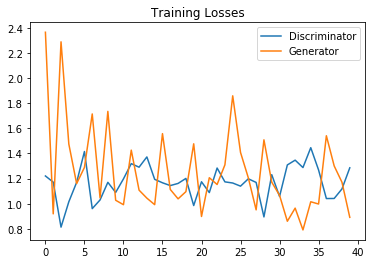

```python
fig, ax = plt.subplots()
losses = np.array(losses)
plt.plot(losses.T[0], label='Discriminator')
plt.plot(losses.T[1], label='Generator')
plt.title("Training Losses")
plt.legend()
```

**Experiment 2**. Use the same leaky relu layer with each fc layer, w/ `with torch.no_grad()` for generator, w relu&tanh saved in init (using `torch.nn.f` directly).

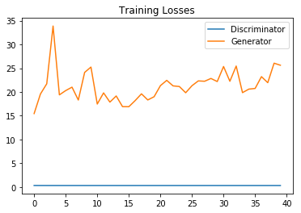

```python
fig, ax = plt.subplots()
losses = np.array(losses)
plt.plot(losses.T[0], label='Discriminator')
plt.plot(losses.T[1], label='Generator')
plt.title("Training Losses")
plt.legend()
```

**Experiment 3**. Use a different leaky relu layer with each fc layer, w/o `with torch.no_grad()` for generator, w relu&tanh saved in init (using `torch.nn.f` directly).

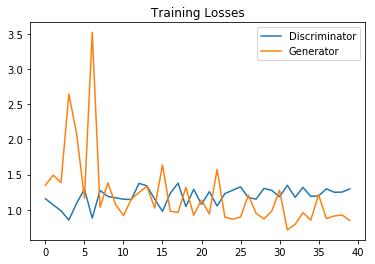

```python
fig, ax = plt.subplots()
losses = np.array(losses)
plt.plot(losses.T[0], label='Discriminator')
plt.plot(losses.T[1], label='Generator')
plt.title("Training Losses")
plt.legend()
```

**Experiment 4**. Use a different leaky relu layer with each fc layer, w/o `with torch.no_grad()` for generator, w/o relu&tanh saved in init (using `torch.nn.functional.f` instead of `torch.nn.f`).

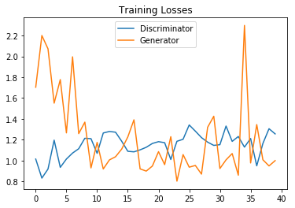

```python
fig, ax = plt.subplots()
losses = np.array(losses)
plt.plot(losses.T[0], label='Discriminator')
plt.plot(losses.T[1], label='Generator')
plt.title("Training Losses")
plt.legend()
```

**Experiment 3**. Use a different leaky relu layer with each fc layer, w/o `with torch.no_grad()` for generator, w relu&tanh saved in init (using `torch.nn.f` directly).

## Generator samples from training

Here we can view samples of images from the generator. First we'll look at the images we saved during training.

```python
# helper function for viewing a list of passed in sample images
def view_samples(epoch, samples):
    fig, axes = plt.subplots(figsize=(7,7), nrows=4, ncols=4, sharey=True, sharex=True)
    for ax, img in zip(axes.flatten(), samples[epoch]):
        img = img.detach()
        ax.xaxis.set_visible(False)
        ax.yaxis.set_visible(False)
        im = ax.imshow(img.reshape((28,28)), cmap='Greys_r')
```

```python
# Load samples from generator, taken while training
with open('train_samples.pkl', 'rb') as f:
    samples = pkl.load(f)
```

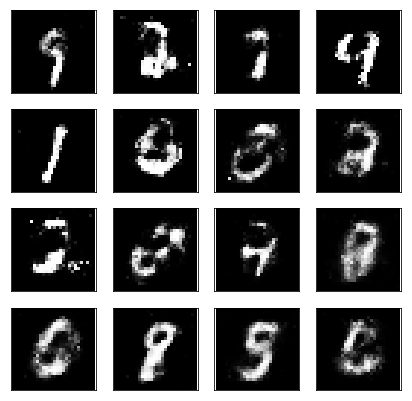

```python
# -1 indicates final epoch's samples (the last in the list)
view_samples(-1, samples)
```

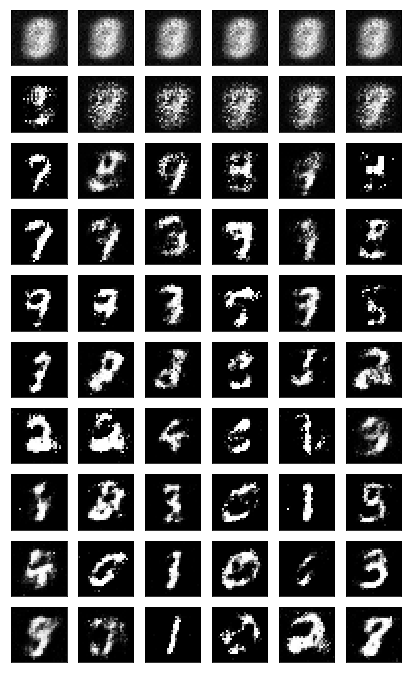

```python
rows = 10 # split epochs into 10, so 100/10 = every 10 epochs
cols = 6
fig, axes = plt.subplots(figsize=(7,12), nrows=rows, ncols=cols, sharex=True, sharey=True)

for sample, ax_row in zip(samples[::int(len(samples)/rows)], axes):
    for img, ax in zip(sample[::int(len(sample)/cols)], ax_row):
        img = img.detach()
        ax.imshow(img.reshape((28,28)), cmap='Greys_r')
        ax.xaxis.set_visible(False)
        ax.yaxis.set_visible(False)
```

It starts out as all noise. Then it learns to make only the center white and the rest black. You can start to see some number like structures appear out of the noise like 1s and 9s.

## Sampling from the generator

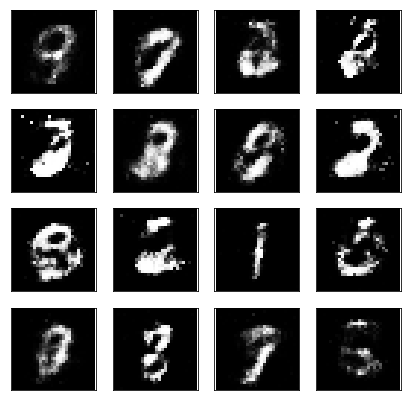

```python
# randomly generated, new latent vectors
sample_size=16
rand_z = np.random.uniform(-1, 1, size=(sample_size, z_size))
rand_z = torch.from_numpy(rand_z).float()

G.eval() # eval mode
# generated samples
rand_images = G(rand_z)

# 0 indicates the first set of samples in the passed in list
# and we only have one batch of samples, here
view_samples(0, [rand_images])
```

**Experiment 4**. Use a different leaky relu layer with each fc layer, w/o `with torch.no_grad()` for generator, w/o relu&tanh saved in init (using `torch.nn.functional.f` instead of `torch.nn.f`).

## Generator samples from training

Here we can view samples of images from the generator. First we'll look at the images we saved during training.

```python
# helper function for viewing a list of passed in sample images
def view_samples(epoch, samples):
    fig, axes = plt.subplots(figsize=(7,7), nrows=4, ncols=4, sharey=True, sharex=True)
    for ax, img in zip(axes.flatten(), samples[epoch]):
        img = img.detach()
        ax.xaxis.set_visible(False)
        ax.yaxis.set_visible(False)
        im = ax.imshow(img.reshape((28,28)), cmap='Greys_r')
```

```python
# Load samples from generator, taken while training
with open('train_samples.pkl', 'rb') as f:
    samples = pkl.load(f)
```

These are samples from the final training epoch. You can see the generator is able to reproduce numbers like 1, 7, 3, 2. Since this is just a sample, it isn't representative of the full range of images this generator can make.

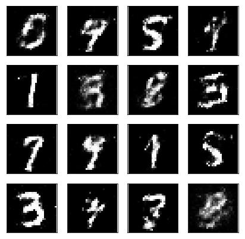

```python
# -1 indicates final epoch's samples (the last in the list)
view_samples(-1, samples)
```

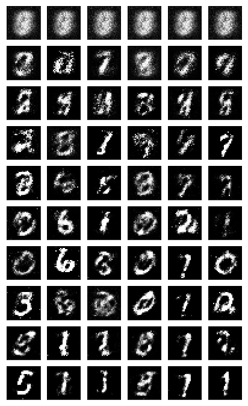

```python
rows = 10 # split epochs into 10, so 100/10 = every 10 epochs
cols = 6
fig, axes = plt.subplots(figsize=(7,12), nrows=rows, ncols=cols, sharex=True, sharey=True)

for sample, ax_row in zip(samples[::int(len(samples)/rows)], axes):
    for img, ax in zip(sample[::int(len(sample)/cols)], ax_row):
        img = img.detach()
        ax.imshow(img.reshape((28,28)), cmap='Greys_r')
        ax.xaxis.set_visible(False)
        ax.yaxis.set_visible(False)
```

It starts out as all noise. Then it learns to make only the center white and the rest black. You can start to see some number like structures appear out of the noise like 1s and 9s.

## Sampling from the generator

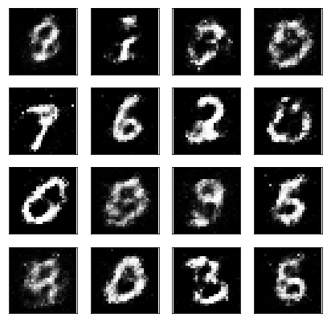

```python
# randomly generated, new latent vectors
sample_size=16
rand_z = np.random.uniform(-1, 1, size=(sample_size, z_size))
rand_z = torch.from_numpy(rand_z).float()

G.eval() # eval mode
# generated samples
rand_images = G(rand_z)

# 0 indicates the first set of samples in the passed in list
# and we only have one batch of samples, here
view_samples(0, [rand_images])
```